# Term Deposit Subscription Prediction_Project_3_solution

```python
print (pd.DataFrame(dTreeR.feature_importances_, columns = ["Imp"], index = X_train.columns))
```

```
                Imp
age        0.010557
job        0.001235
marital    0.000847
education  0.002670
default    0.001299
balance    0.005904
housing    0.082183
loan       0.001327
contact    0.145281
day        0.006371
month      0.083570
duration   0.569158
campaign   0.002713
pdays      0.076545
previous   0.010341
```

Duration is very important feature.

```
0.8875722817328656
0.8894131524624005
```

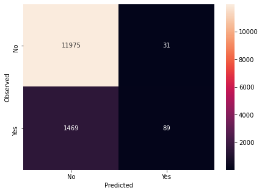

```
Recall: 0.05712451861360719

Precision: 0.7416666666666667

F1 Score: 0.10607866507747318

Roc Auc Score: 0.527271238150715
```

```python
from sklearn.ensemble import RandomForestClassifier
rfcl = RandomForestClassifier(criterion = 'entropy', class_weight={0:.5,1:.5}, max_depth = 6, min_samples_leaf=5)
rfcl = rfcl.fit(X_train, Y_train)
Y_predict = rfcl.predict(X_test)

print(rfcl.score(X_train , Y_train))
print(rfcl.score(X_test , Y_test))

cm=metrics.confusion_matrix(Y_test, Y_predict, labels=[0, 1])

df_cm = pd.DataFrame(cm, index = [i for i in ["No","Yes"]],
                  columns = [i for i in ["No","Yes"]])
plt.figure(figsize = (7,5))
sns.heatmap(df_cm, annot=True ,fmt='g')
plt.ylabel('Observed')
plt.xlabel('Predicted')
plt.show()

print("Recall:",recall_score(Y_test,Y_predict))
print()
print("Precision:",precision_score(Y_test,Y_predict))
print()
print("F1 Score:",f1_score(Y_test,Y_predict))
print()
print("Roc Auc Score:",roc_auc_score(Y_test,Y_predict))
```

```python
cmd=cmd.append({'Model':'Rfcl','training_accuracy':rfcl.score(X_train, Y_train) ,'testing_accuracy':rfcl.score(X_test, Y_test),'Recall': recall_score(Y_test,Y_predict), 'Precision': precision_score(Y_test,Y_predict),
            'F1 Score': f1_score(Y_test,Y_predict), 'RocAucScore':roc_auc_score(Y_test,Y_predict)}, ignore_index=True)
```

Bagging:

```
0.9998420071412772
0.9040843409023887
```

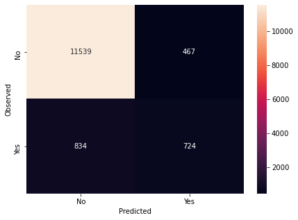

```
Recall: 0.46469833119383824

Precision: 0.6078925272879933

F1 Score: 0.5267369952710076

Roc Auc Score: 0.7129005565681001
```

```python
from sklearn.ensemble import BaggingClassifier
bgcl = BaggingClassifier(base_estimator=dTree, n_estimators=50,random_state=10)
bgcl = bgcl.fit(X_train, Y_train)
Y_predict = bgcl.predict(X_test)

print(bgcl.score(X_train , Y_train))
print(bgcl.score(X_test , Y_test))

cm=metrics.confusion_matrix(Y_test, Y_predict,labels=[0, 1])

df_cm = pd.DataFrame(cm, index = [i for i in ["No","Yes"]],
                  columns = [i for i in ["No","Yes"]])
plt.figure(figsize = (7,5))
sns.heatmap(df_cm, annot=True ,fmt='g')
plt.ylabel('Observed')
plt.xlabel('Predicted')
plt.show()

print("Recall:",recall_score(Y_test,Y_predict))
print()
print("Precision:",precision_score(Y_test,Y_predict))
print()
print("F1 Score:",f1_score(Y_test,Y_predict))
print()
print("Roc Auc Score:",roc_auc_score(Y_test,Y_predict))
```

```python
cmd=cmd.append({'Model':'Bgcl','training_accuracy':bgcl.score(X_train, Y_train) ,'testing_accuracy':bgcl.score(X_test, Y_test),'Recall': recall_score(Y_test,Y_predict), 'Precision': precision_score(Y_test,Y_predict),
            'F1 Score': f1_score(Y_test,Y_predict), 'RocAucScore':roc_auc_score(Y_test,Y_predict)}, ignore_index=True)
```

Adaboosting:

```
0.8887730274591589
0.8899292244175759
```

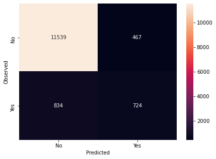

```
Recall: 0.46469833119383824

Precision: 0.6078925272879933

F1 Score: 0.5267369952710076

Roc Auc Score: 0.7129005565681001
```

```python
from sklearn.ensemble import AdaBoostClassifier
abcl = AdaBoostClassifier(n_estimators=10, random_state=10)
abcl = abcl.fit(X_train, Y_train)
y_predict = abcl.predict(X_test)

print(abcl.score(X_train , Y_train))
print(abcl.score(X_test , Y_test))

cm=metrics.confusion_matrix(Y_test, Y_predict,labels=[0, 1])

df_cm = pd.DataFrame(cm, index = [i for i in ["No","Yes"]],
                  columns = [i for i in ["No","Yes"]])
plt.figure(figsize = (7,5))
sns.heatmap(df_cm, annot=True ,fmt='g')
plt.ylabel('Observed')
plt.xlabel('Predicted')
plt.show()

print("Recall:",recall_score(Y_test,Y_predict))
print()
print("Precision:",precision_score(Y_test,Y_predict))
print()
print("F1 Score:",f1_score(Y_test,Y_predict))
print()
print("Roc Auc Score:",roc_auc_score(Y_test,Y_predict))
```

```python
cmd=cmd.append({'Model':'Abcl','training_accuracy':abcl.score(X_train, Y_train) ,'testing_accuracy':abcl.score(X_test, Y_test),'Recall': recall_score(Y_test,Y_predict), 'Precision': precision_score(Y_test,Y_predict),
            'F1 Score': f1_score(Y_test,Y_predict), 'RocAucScore':roc_auc_score(Y_test,Y_predict)}, ignore_index=True)
```

```
0.8991689575631181
0.897817752875258
```

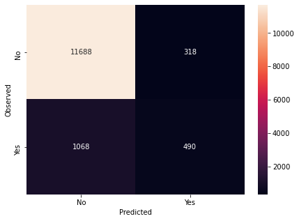

```
Recall: 0.31450577663671375

Precision: 0.6064356435643564

F1 Score: 0.41420118343195267

Roc Auc Score: 0.6440095100075122
```

```python
from sklearn.ensemble import GradientBoostingClassifier
gbcl = GradientBoostingClassifier(n_estimators = 50,random_state=1)
gbcl = gbcl.fit(X_train, Y_train)
Y_predict = gbcl.predict(X_test)

print(gbcl.score(X_train , Y_train))
print(gbcl.score(X_test, Y_test))

cm=metrics.confusion_matrix(Y_test, Y_predict,labels=[0, 1])

df_cm = pd.DataFrame(cm, index = [i for i in ["No","Yes"]],
                  columns = [i for i in ["No","Yes"]])
plt.figure(figsize = (7,5))
sns.heatmap(df_cm, annot=True ,fmt='g')
plt.ylabel('Observed')
plt.xlabel('Predicted')
plt.show()

print("Recall:",recall_score(Y_test,Y_predict))
print()
print("Precision:",precision_score(Y_test,Y_predict))
print()
print("F1 Score:",f1_score(Y_test,Y_predict))
print()
print("Roc Auc Score:",roc_auc_score(Y_test,Y_predict))
```

```python
cmd=cmd.append({'Model':'Gbcl','training_accuracy':gbcl.score(X_train, Y_train) ,'testing_accuracy':gbcl.score(X_test, Y_test),'Recall': recall_score(Y_test,Y_predict), 'Precision': precision_score(Y_test,Y_predict),
            'F1 Score': f1_score(Y_test,Y_predict), 'RocAucScore':roc_auc_score(Y_test,Y_predict)}, ignore_index=True)
```

Compare model dataframe:

```python
cmd.sort_values(by=['Recall'],ascending=False,inplace=True )
```

```python
print (cmd)
```

```
    Model  training_accuracy  testing_accuracy    Recall  Precision  F1 Score  \
3    Bgcl           0.999842          0.904084  0.464698   0.607893  0.526737
4    Abcl           0.888773          0.889929  0.464698   0.607893  0.526737
1   DTree           0.897842          0.897670  0.394095   0.580340  0.469419
5    Gbcl           0.899169          0.897818  0.314506   0.606436  0.414201
0  Logreg           0.888299          0.891551  0.181643   0.590814  0.277860
2    Rfcl           0.887572          0.889413  0.057125   0.741667  0.106079

   RocAucScore
3     0.712901
4     0.712901
1     0.678557
5     0.644010
0     0.582659
2     0.527271
```

Conclusion:

Here we want to build a model that will help the marketing team identify potential customers who are relatively more likely to subscribe term deposit and thus increase their hit ratio.

So, in this case hit rate should be greater , hence recall is an important metric.

We can deploy the model for practical use, after achieving desired outcome. As here,we can predict which customer is going to subscribe term deposit. Customer who are contacted for large duration are more likely to subscribe term deposit.